# Praca domowa 3

### Klaudia Gruszkowska

```python
#wczytanie pakietów
import pandas as pd
import numpy as np
import sklearn
import seaborn as sns
import matplotlib.pyplot as plt
import matplotlib
from sklearn.metrics import roc_auc_score
from sklearn.metrics import accuracy_score
from sklearn.metrics import precision_score
from sklearn.metrics import recall_score
import matplotlib.pyplot as plt
from sklearn.ensemble import RandomForestClassifier
from sklearn.tree import DecisionTreeClassifier,plot_tree
from sklearn.linear_model import LogisticRegression
from sklearn.metrics import plot_confusion_matrix
import plotly.graph_objects as go
from plotly.colors import n_colors
from sklearn.model_selection import cross_val_score
from sklearn.model_selection import StratifiedKFold
```

```python
#wczytanie danych
australia = pd.read_csv("australia.csv")
```

```python
australia.head()
```

|  | MinTemp | MaxTemp | Rainfall | Evaporation | Sunshine | WindGustSpeed | WindSpeed9am | WindSpeed3pm | Humidity9am | Humidity3pm | Pressure9am | Pressure3pm | Cloud9am | Cloud3pm | Temp9am | Temp3pm | RainToday | RainTomorrow |
| --- | --- | --- | --- | --- | --- | --- | --- | --- | --- | --- | --- | --- | --- | --- | --- | --- | --- | --- |
| 0 | 17.9 | 35.2 | 0.0 | 12.0 | 12.3 | 48.0 | 6.0 | 20.0 | 20.0 | 13.0 | 1006.3 | 1004.4 | 2.0 | 5.0 | 26.6 | 33.4 | 0 | 0 |
| 1 | 18.4 | 28.9 | 0.0 | 14.8 | 13.0 | 37.0 | 19.0 | 19.0 | 30.0 | 8.0 | 1012.9 | 1012.1 | 1.0 | 1.0 | 20.3 | 27.0 | 0 | 0 |
| 2 | 19.4 | 37.6 | 0.0 | 10.8 | 10.6 | 46.0 | 30.0 | 15.0 | 42.0 | 22.0 | 1012.3 | 1009.2 | 1.0 | 6.0 | 28.7 | 34.9 | 0 | 0 |
| 3 | 21.9 | 38.4 | 0.0 | 11.4 | 12.2 | 31.0 | 6.0 | 6.0 | 37.0 | 22.0 | 1012.7 | 1009.1 | 1.0 | 5.0 | 29.1 | 35.6 | 0 | 0 |
| 4 | 24.2 | 41.0 | 0.0 | 11.2 | 8.4 | 35.0 | 17.0 | 13.0 | 19.0 | 15.0 | 1010.7 | 1007.4 | 1.0 | 6.0 | 33.6 | 37.6 | 0 | 0 |

```python
australia.info()
```

```
<class 'pandas.core.frame.DataFrame'>
RangeIndex: 56420 entries, 0 to 56419
Data columns (total 18 columns):
 #   Column         Non-Null Count  Dtype
---  ------         --------------  -----
 0   MinTemp        56420 non-null  float64
 1   MaxTemp        56420 non-null  float64
 2   Rainfall       56420 non-null  float64
 3   Evaporation    56420 non-null  float64
 4   Sunshine       56420 non-null  float64
 5   WindGustSpeed  56420 non-null  float64
 6   WindSpeed9am   56420 non-null  float64
 7   WindSpeed3pm   56420 non-null  float64
 8   Humidity9am    56420 non-null  float64
 9   Humidity3pm    56420 non-null  float64
 10  Pressure9am    56420 non-null  float64
 11  Pressure3pm    56420 non-null  float64
 12  Cloud9am       56420 non-null  float64
 13  Cloud3pm       56420 non-null  float64
 14  Temp9am        56420 non-null  float64
 15  Temp3pm        56420 non-null  float64
 16  RainToday      56420 non-null  int64
 17  RainTomorrow   56420 non-null  int64
dtypes: float64(16), int64(2)
memory usage: 7.7 MB
```

```python
australia.describe()
```

|  | MinTemp | MaxTemp | Rainfall | Evaporation | Sunshine | WindGustSpeed | WindSpeed9am | WindSpeed3pm | Humidity9am | Humidity3pm | Pressure9am | Pressure3pm | Cloud9am | Cloud3pm | Temp9am | Temp3pm | RainToday | RainTomorrow |
| --- | --- | --- | --- | --- | --- | --- | --- | --- | --- | --- | --- | --- | --- | --- | --- | --- | --- | --- |
| count | 56420.000000 | 56420.000000 | 56420.000000 | 56420.000000 | 56420.000000 | 56420.000000 | 56420.000000 | 56420.000000 | 56420.000000 | 56420.000000 | 56420.000000 | 56420.000000 | 56420.000000 | 56420.000000 | 56420.000000 | 56420.000000 | 56420.000000 | 56420.000000 |
| mean | 13.464770 | 24.219206 | 2.130397 | 5.503135 | 7.735626 | 40.877366 | 15.667228 | 19.786778 | 65.874123 | 49.601985 | 1017.239505 | 1014.795580 | 4.241705 | 4.326515 | 18.204961 | 22.710333 | 0.220879 | 0.220259 |
| std | 6.416689 | 6.970676 | 7.014822 | 3.696282 | 3.758153 | 13.335232 | 8.317005 | 8.510180 | 18.513289 | 20.197040 | 6.909357 | 6.870892 | 2.797162 | 2.647251 | 6.567991 | 6.836543 | 0.414843 | 0.414425 |
| min | -6.700000 | 4.100000 | 0.000000 | 0.000000 | 0.000000 | 9.000000 | 2.000000 | 2.000000 | 0.000000 | 0.000000 | 980.500000 | 977.100000 | 0.000000 | 0.000000 | -0.700000 | 3.700000 | 0.000000 | 0.000000 |
| 25% | 8.600000 | 18.700000 | 0.000000 | 2.800000 | 5.000000 | 31.000000 | 9.000000 | 13.000000 | 55.000000 | 35.000000 | 1012.700000 | 1010.100000 | 1.000000 | 2.000000 | 13.100000 | 17.400000 | 0.000000 | 0.000000 |
| 50% | 13.200000 | 23.900000 | 0.000000 | 5.000000 | 8.600000 | 39.000000 | 15.000000 | 19.000000 | 67.000000 | 50.000000 | 1017.200000 | 1014.700000 | 5.000000 | 5.000000 | 17.800000 | 22.400000 | 0.000000 | 0.000000 |
| 75% | 18.400000 | 29.700000 | 0.600000 | 7.400000 | 10.700000 | 48.000000 | 20.000000 | 26.000000 | 79.000000 | 63.000000 | 1021.800000 | 1019.400000 | 7.000000 | 7.000000 | 23.300000 | 27.900000 | 0.000000 | 0.000000 |
| max | 31.400000 | 48.100000 | 206.200000 | 81.200000 | 14.500000 | 124.000000 | 67.000000 | 76.000000 | 100.000000 | 100.000000 | 1040.400000 | 1038.900000 | 8.000000 | 9.000000 | 39.400000 | 46.100000 | 1.000000 | 1.000000 |

```python
s1 = australia['RainTomorrow'].value_counts().rename_axis('RainTomorrow').reset_index(name='counts')
s1
```

|  | RainTomorrow | counts |
| --- | --- | --- |
| 0 | 0 | 43993 |
| 1 | 1 | 12427 |

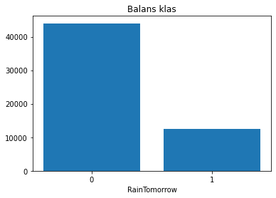

```python
plt.bar(s1['RainTomorrow'], s1['counts'])
plt.title("Balans klas")
plt.xlabel("RainTomorrow")
x_pos = [0,1]
plt.xticks(x_pos, [0,1])
plt.show()
```

Dane są niezbalansowane. Należy na to zwrócić uwagę w późniejszej analizie.

## Dane niezbalansowane

### Podział danych na zbiór testowych i treningowych

```python
from sklearn.model_selection import train_test_split
y = np.array(australia['RainTomorrow'])
X = australia.drop(['RainTomorrow'],axis=1)

X_train, X_val, y_train, y_val = train_test_split(X, y, test_size=0.3, random_state=42,stratify = y)
X_val, X_test, y_val, y_test = train_test_split(X_val, y_val, test_size=0.3, random_state=42)
```

Z powodu braku zbalansowania zmiennej celu używaż hiperparametru stratify aby zbiór testowy i treningowy miał taki sam balans jaki jest w zbiorze.

```python
np.unique(y_test, return_counts=True)
```

```
(array([0, 1], dtype=int64), array([3957, 1121], dtype=int64))
```

```python
X_train_val=pd.concat((X_train,X_val))
y_train_val=np.concatenate((y_train,y_val), axis=0)
```

### Klasyfikatory

```python
auc = []
recall = []
precision = []

def model(model):

    model.fit(X_train, y_train)

    y_hat = model.predict(X_val)

    skf = StratifiedKFold(n_splits=5)

    auc_scores = cross_val_score(model, X_train_val, y_train_val, cv=skf, scoring='roc_auc')
    recall_scores =cross_val_score(model, X_train_val, y_train_val, cv=skf, scoring='recall')
    precision_scores = cross_val_score(model, X_train_val, y_train_val, cv=skf, scoring='precision')

    auc_mean = np.mean(auc_scores)
    auc_std = np.std(auc_scores)
    recall_mean = np.mean(recall_scores)
    recall_std = np.std(recall_scores)
    precision_mean = np.mean(precision_scores)
    precision_std = np.std(precision_scores)

    auc.append( str(round(auc_mean,4))+"+/-"+str(round(auc_std,4)))
    recall.append( str(round(recall_mean,4))+"+/-"+str(round(recall_std,4)))
    precision.append( str(round(precision_mean,4))+"+/-"+str(round(precision_std,4)))


    print("auc      mean ",auc_mean)
    print("         std ",auc_std)
    print("recall    mean",recall_mean)
    print("          std",recall_std)
    print("precision mean",precision_mean)
    print("          std",precision_std)

    df1 = pd.DataFrame({'type': 'auc', 'val': auc_scores})
    df2 = pd.DataFrame({'type': 'recall','val': recall_scores})
    df3 = pd.DataFrame({'type': 'precision', 'val':precision_scores})
    df = df1.append(df2)
    df = df.append(df3)

    plt.figure(figsize=(8, 12))
    ax = sns.boxplot(x="type", y="val", data=df)
    ax.set_ylim([0, 1])
    plt.title('Score')

    plot_confusion_matrix(model, X_test, y_test)
    plt.title('Confusion matrix')
```

```
auc      mean  0.8804947585391776
         std  0.0034339370556240364
recall    mean 0.5265343496047029
          std 0.00866387896537178
precision mean 0.7274895066214556
          std 0.008079234207586355
```

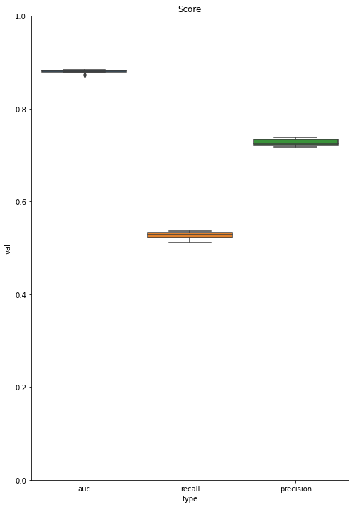

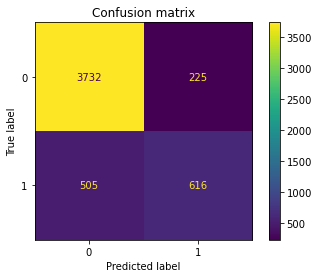

```python
model(LogisticRegression( max_iter = 2000))
```

W modelu regresji logistycznej ustawionym przeze mnie hiperparametrem jest max_iter czyli maksymalna liczba iteracji potrzebnych do osiągnięcia zbieżności. Domyślnie ten parametr ustawiony jest na 100.

```
auc      mean  0.8341924186629981
         std  0.004958186770073529
recall    mean 0.5097295821860784
          std 0.011606153300029917
precision mean 0.6751174622153033
          std 0.019020861509531736
```

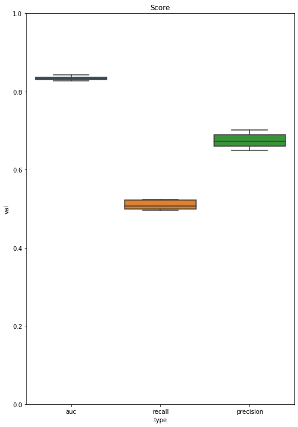

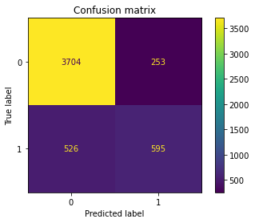

```python
model(DecisionTreeClassifier(max_depth = 10))
```

W modelu drzewa decyzyjnego ustawionym przeze mnie hiperparametrem jest max_depth czyli maksymalna głębokość drzewa. Domyślnie ustawiony jest na None, wtedy drzewo będzie rozwijane aż do momentu gdy liczba próbek w liście będzie mniejsza od ustawionego parametru min_samples_split (który domyślnie jest równy 2).

```
auc      mean  0.8874610908600047
         std  0.0037266332230006713
recall    mean 0.4990270965289648
          std 0.01258725729908272
precision mean 0.7642214570971335
          std 0.01211636020779416
```

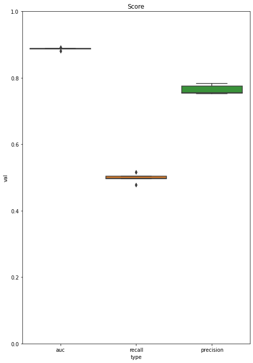

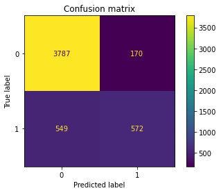

```python
model(RandomForestClassifier(n_estimators = 200,max_depth = 10))
```

W modelu lasu losowego ustawionym przeze mnie hiperparametrem są n_estimators i max_depth. Max_depth oznacza maksymalną głębokość każdego z drzew w lesie i domyślnie ustawiony jest na None (wytłumaczone powyżej). N_estimators oznacza ilość drzew w lesie. Domyślnie ustawiony jest na 100.

Na pierwszy rzut oka widać znaczącą przewagę dobrej predyckji dla klasy 0. Jednak tak duża różnica spowodowana jest ilością tych obserwacji w zbiorze. Co nie zmienia faktu, że dopasowanie klasy 1 jest słabe. Około połowę obserwacji klasy 1 zostało błędnie przypisanych.

## Wyniki

```python
def results():


    fig = go.Figure(data=[go.Table(header=dict(values=['model','recall','precision','auc']),
                     cells=dict(values=[['LogisticRegression','DecisionTree','RandomForest'] , recall, precision, auc],
                                ))
                         ])
    fig.update_layout(
        autosize=False,
        width=900,
        height=300,)
    fig.show()
```

```python
results()
```

[interactive chart not shown]

Przy tak niezbalansowanym zbiorze danych nie możemy zastosowac np. miary accuracy, ponieważ nie doprowadzi nas to prawidłowych wniosków. Gdyby model wszystkie nasze wartości uznał za 0 to miałby sporą wartość accuracy tylko dlatego, że 0 przeważa w tym zbiorze.

Przy takiech wynikach ciężko stwierdzić, który model jest najlepszy. Wyniki są bardzo zbliżone. Wydaje się, że drzewo decyzyjne wypada najsłabiej. W zależności od miary wygrywa albo las losowy albo regresja logistyczna. Patrząc na macierz pomyłek wydaje się, że to las losowy trochę lepiej przyporządkowuje poprawne etykiety.

### Spróbuję dokonać zbalansowania danych za pomocą metody upsampling czyli dopisaniu kopii obserwacji z klasy mniejszościowej.

## Dane zbalansowane

```
0    43993
1    43993
Name: RainTomorrow, dtype: int64
```

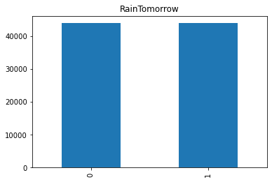

```python
# Ponieważ dane są niezbalansowane wykonuję upsampling czyli "dopisanie" skopiowanych obserwacji z klasy mniejszej
count_class_0, count_class_1 = australia.RainTomorrow.value_counts()

# Divide by class
df_class_0 = australia[australia['RainTomorrow'] == 0]
df_class_1 = australia[australia['RainTomorrow'] == 1]

df_class_1_over = df_class_1.sample(count_class_0, replace=True)
australia = pd.concat([df_class_0, df_class_1_over], axis=0)

print(australia.RainTomorrow.value_counts())

australia.RainTomorrow.value_counts().plot(kind='bar', title='RainTomorrow');
```

```python
from sklearn.model_selection import train_test_split
y = np.array(australia['RainTomorrow'])
X = australia.drop(['RainTomorrow'],axis=1)

X_train, X_val, y_train, y_val = train_test_split(X, y, test_size=0.3, random_state=42,stratify = y)
X_val, X_test, y_val, y_test = train_test_split(X_val, y_val, test_size=0.3, random_state=42)
```

```python
np.unique(y_test, return_counts=True)
```

```
(array([0, 1], dtype=int64), array([3948, 3971], dtype=int64))
```

```python
X_train_val=pd.concat((X_train,X_val))
y_train_val=np.concatenate((y_train,y_val), axis=0)
```

## Klaysfikatory

W poniższych modelach zostawiam takie same hiperparametry

```python
auc=[]
recall =[]
precision = []
```

```
auc      mean  0.8793614691885597
         std  0.0017970939221948424
recall    mean 0.7848683902895522
          std 0.0069208336521192244
precision mean 0.8008424075865299
          std 0.002916596152994871
```

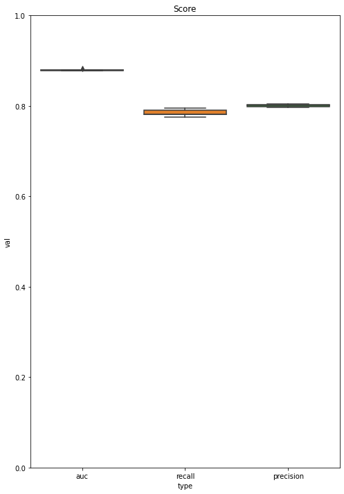

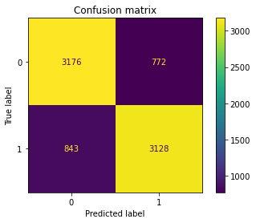

```python
model(LogisticRegression( max_iter = 2000))
```

```
auc      mean  0.8913882896586431
         std  0.0028223288175557486
recall    mean 0.846909543354494
          std 0.0133648272709717
precision mean 0.7929346333452572
          std 0.007854462500235597
```

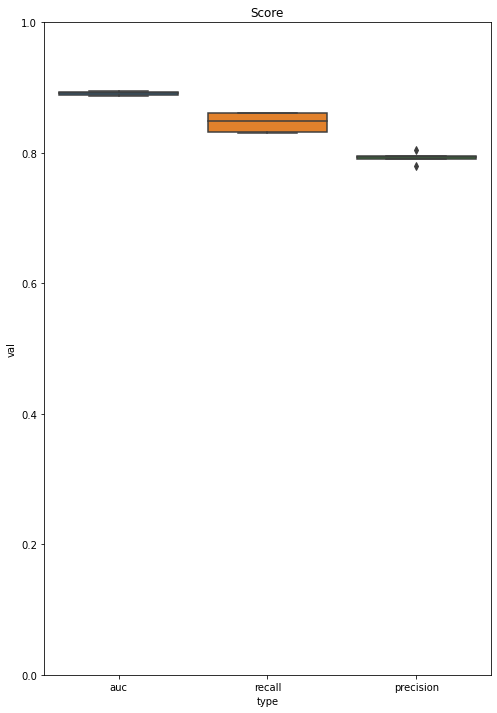

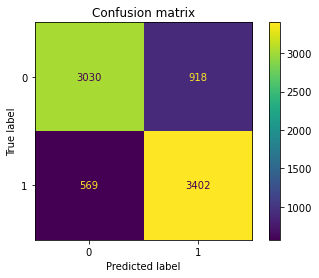

```python
model(DecisionTreeClassifier(max_depth = 10))
```

```
auc      mean  0.9191513049928645
         std  0.0008767012904516843
recall    mean 0.8634500395024224
          std 0.005291461105930014
precision mean 0.8243637510164321
          std 0.002794970109681193
```

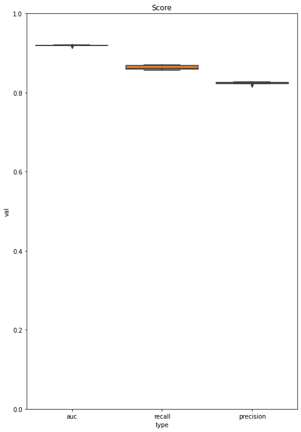

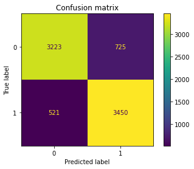

```python
model(RandomForestClassifier(n_estimators = 200,max_depth = 10))
```

Widać dużą różnicę w macierzach pomyłek w porównaniu do wcześniejszych niezbalansowanych danych. W tym przypadku widać przeważające liczbę poprawnie zakwalifikowanych obserwacji. Podczas upsamplingu dodawaliśmy kopie obserwacji, których zmienna celu czyli RainTomorrow jest równa 1, co może tłumaczyć większą poprawność w dopasowywaniu tych właśnie obserwacji.

## Wyniki

```python
results()
```

[interactive chart not shown]